# Equitable Equations Supplemental

# Gamma Distribution

A continuous probability distribution used to model the time that elapses before $\alpha$ occurrences of a randomly occurring event.

Shape $\alpha$ and Scale $\theta$ . Sometimes the rate parameter $\lambda=1/\theta$ is used instead of $\theta$. Since $\theta$ is the average time between occurrences, $\lambda$ is the number of occurrences per unit time.

## `rgamma()`

`rgamma(n, shape, rate = 1, scale = 1/rate)`

Generates $n$ random values from the gamma distribution with shape $\alpha$ and rate $\lambda$.

Generates 6 random variables from the gamma distribution The time needed for 2 occurences with a mean density of 0.5 per unit time:

```r
rgamma(6, 2, .5)
```

```
## [1] 4.842787 5.938712 2.056875 3.450727 1.223926 1.907370
```

Alternatively, using $\theta$

```r
rgamma(6, 2, scale=2)
```

```
## [1]  4.730805  1.082111  2.468344 14.179379  4.723485  5.114775
```

## `pgamma`

`pgamma(q, shape, rate = 1, scale = 1/rate, lower.tail = TRUE, log.p = FALSE)`

The cumulative distribution function. Returns the probability that the waiting time for $\alpha$ occurences is no more than $x$.

Gives the waiting time $\le$ to 1, 2, $\dots$, 6 units of time.

```r
pgamma(1:6, 2, .5)
```

```
## [1] 0.09020401 0.26424112 0.44217460 0.59399415 0.71270250 0.80085173
```

## `qgamma`

The inverse of `pgamma`.

`qgamma(p, shape, rate = 1, scale = 1/rate, lower.tail = TRUE, log.p = FALSE)`

Computes quantiles in the specified distribution. $p$ is a vector of probabilities.

```r
qgamma(c(.2, .4, .6, .8), 2, .5)
```

```
## [1] 1.648777 2.752843 4.044626 5.988617
```

## `dgamma`

dgamma(x, shape, rate = 1, scale = 1/rate, log = FALSE)

The probability density function. Mainly used in R for generating graphs

```r
library(tidyverse)
```

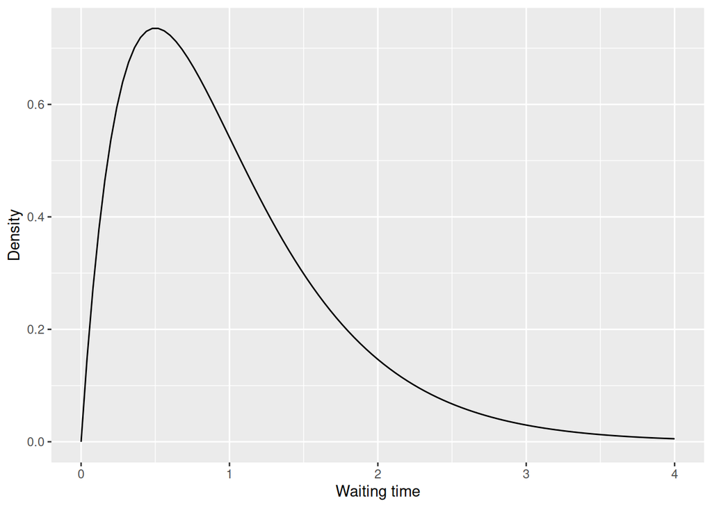

```r
ggplot() +
  xlim(c(0,4)) +
  geom_function(fun = dgamma,
                args = list(shape=2, scale=.5)) +
  labs(x = "Waiting time", y = "Density")
```

# Example

Calls to a customer service line come in at an average rate of 1 every 3 minutes. Note that the rate is actually $/theta$. The equivalent $\lambda$ would be the average number of occurences per unit time, ie. 1/3 per minute.

1. What is the probability that more than an hour elapses before 25 calls come in?

With $\lambda$:

```r
1 - pgamma(60, 25, 1/3)
```

```
## [1] 0.8432274
```

With $\theta$

```r
1 - pgamma(60, 25, scale = 3)
```

```
## [1] 0.8432274
```

2. What is the 95th percentile for time neede for 5 calls to come in?

```r
qgamma(.95, 5, 1/3)
```

```
## [1] 27.46056
```

3. Simulate waiting times for 5 calls 1000 times and plot the results.

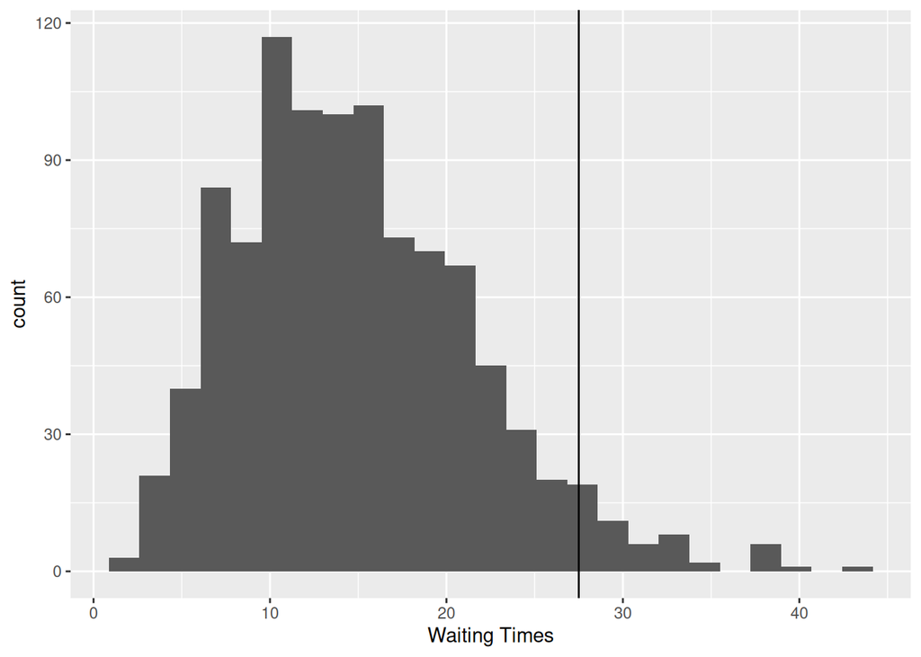

```r
times <- rgamma(1000, 5, 1/3)
library(tidyverse)
data.frame(times) |>
  ggplot(aes(times)) +
  geom_histogram(bins = 25) +
  xlab("Waiting Times") +
  geom_vline(xintercept = 27.5)
```